# Time Series S05

Group 3

6/23/2020

## DATA 624 Summer 2020, Project #1

Format: Group Effort, Group Representative will turn in your assignment. No conversations across groups regarding this project. DUE: 6/27/20 by Midnight ET Submission: Via Email – scott.burk@sps.cuny.edu Submission: Word Readable Document for Report (all in one), Excel Readable (all in one, separate sheets). File Convention: Group#_Project1_Summer624, example Group1_Project1_Summer624 GRADE: 70% Report, 30% Forecast Accuracy

### Overview

Your data is a de-identified Excel spreadsheet. Your assignment is to perform the appropriate analysis to forecast several series for 140 periods. You will have 1622 periods for your analysis. See Requirement #2 for more details.

### Requirement #1

You will turn in a written report. You need to write this report as if it the report will be routed in an office to personnel of vary different backgrounds. You need to be able to reach readers that have no data science background to full fledge data scientists. So, you need to explain what you have done, why and how you did it with both layman and technical terminology. Do not simply write this with me in mind. Visuals and output are expected, but it is not necessary to include every bit of analysis. In fact, a terse report with simple terminology is preferred to throwing in everything into a long, ad nausem report. Story telling is really taking on for data science, so please flex your muscles here. The report is part 1 of 2 requirements.

NOTE: We have covered a lot of material. I don’t want you to try every method to create your forecast. But you should perform fundamentals, visualize your data, and perform exploratory data analysis as appropriate.

### Requirement #2

Your second requirement is to produce forecasts. This workbook will contain at least 6 sheets where I will calculate your error rates. There will be one sheet (tab) for each Group – S01, S02, S03, SO4, S05, S06. You should order each sheet by the variable SeriesIND (low to high). Your source data is sorted this way, except there are all 6 groups present in one sheet which you must break out into 6 tabs. You will submit the data I sent AND the forward forecast for 140 periods. I want you to forecast the following

S01 – Forecast Var01, Var02 S02 – Forecast Var02, Var03 S03 – Forecast Var05, Var07 S04 – Forecast Var01, Var02 S05 – Forecast Var02, Var03 S06 – Forecast Var05, Var07

### Group S05

This group S05 is constituated of variables Var02 and Var03. Our goal is to find the best forecast for the variables Var02 and Var03 in S05. For that, we are going to process the dataset to change missing values and ouliers. After some statistic analysis, we can apply several models and check for the accuaracy of those models.

```r
library(fpp2)
library(dplyr)
library(imputeTS)
```

### Load the dataset

```r
full_data <- readxl::read_excel("Data Set for Class.xls")
head(full_data)
```

```
## # A tibble: 6 x 7
##   SeriesInd group Var01     Var02 Var03 Var05 Var07
##       <dbl> <chr> <dbl>     <dbl> <dbl> <dbl> <dbl>
## 1     40669 S03    30.6 123432400  30.3  30.5  30.6
## 2     40669 S02    10.3  60855800  10.0  10.2  10.3
## 3     40669 S01    26.6  10369300  25.9  26.2  26.0
## 4     40669 S06    27.5  39335700  26.8  27.0  27.3
## 5     40669 S05    69.3  27809100  68.2  68.7  69.2
## 6     40669 S04    17.2  16587400  16.9  16.9  17.1
```

### Subset the dataset

```r
dt_s05 <- subset(full_data, group == 'S05', select = c(SeriesInd, Var02, Var03))
summary(dt_s05)
```

```
##    SeriesInd         Var02               Var03
##  Min.   :40669   Min.   :  4156600   Min.   : 55.94
##  1st Qu.:41304   1st Qu.: 11201200   1st Qu.: 77.21
##  Median :41946   Median : 14578800   Median : 84.87
##  Mean   :41945   Mean   : 16791350   Mean   : 82.97
##  3rd Qu.:42586   3rd Qu.: 20021200   3rd Qu.: 89.74
##  Max.   :43221   Max.   :118023500   Max.   :103.95
##                  NA's   :141         NA's   :145
```

#### Get the subsets Var02 and Var03

```r
dt_s05_v2 <- dt_s05 %>% filter(SeriesInd <= 43221) %>% select(Var02)
```

```r
dt_s05_v3 <- dt_s05 %>% filter(SeriesInd <= 43221) %>% select(Var03)
```

Explore the subsets Var02

```r
summary(dt_s05_v2)
```

```
##      Var02
##  Min.   :  4156600
##  1st Qu.: 11201200
##  Median : 14578800
##  Mean   : 16791350
##  3rd Qu.: 20021200
##  Max.   :118023500
##  NA's   :141
```

```r
str(dt_s05_v2)
```

```
## Classes 'tbl_df', 'tbl' and 'data.frame':    1762 obs. of  1 variable:
##  $ Var02: num  27809100 30174700 35044700 27192100 24891800 ...
```

Explore the subsets Var03

```r
summary(dt_s05_v3)
```

```
##      Var03
##  Min.   : 55.94
##  1st Qu.: 77.21
##  Median : 84.87
##  Mean   : 82.97
##  3rd Qu.: 89.74
##  Max.   :103.95
##  NA's   :145
```

```r
str(dt_s05_v3)
```

```
## Classes 'tbl_df', 'tbl' and 'data.frame':    1762 obs. of  1 variable:
##  $ Var03: num  68.2 68.8 69.3 69.4 69.2 ...
```

#### Imputing missing values

```r
dt_s05_v2 <- na_interpolation(dt_s05_v2)
summary(dt_s05_v2)
```

```
##      Var02
##  Min.   :  4156600
##  1st Qu.: 11370000
##  Median : 13912700
##  Mean   : 16358315
##  3rd Qu.: 19355700
##  Max.   :118023500
```

```r
dt_s05_v3 <- na_interpolation(dt_s05_v3)
summary(dt_s05_v3)
```

```
##      Var03
##  Min.   : 55.94
##  1st Qu.: 78.37
##  Median : 85.73
##  Mean   : 83.51
##  3rd Qu.: 89.70
##  Max.   :103.95
```

#### converse Var02 and Var03 to time series

```r
dt_s05_v2 <- ts(dt_s05_v2)
str(dt_s05_v2)
```

```
##  Time-Series [1:1762, 1] from 1 to 1762: 27809100 30174700 35044700 27192100 24891800 ...
##  - attr(*, "dimnames")=List of 2
##   ..$ : NULL
##   ..$ : chr "Var02"
```

```r
dt_s05_v3 <- ts(dt_s05_v3)
str(dt_s05_v3)
```

```
##  Time-Series [1:1762, 1] from 1 to 1762: 68.2 68.8 69.3 69.4 69.2 ...
##  - attr(*, "dimnames")=List of 2
##   ..$ : NULL
##   ..$ : chr "Var03"
```

### Visualization

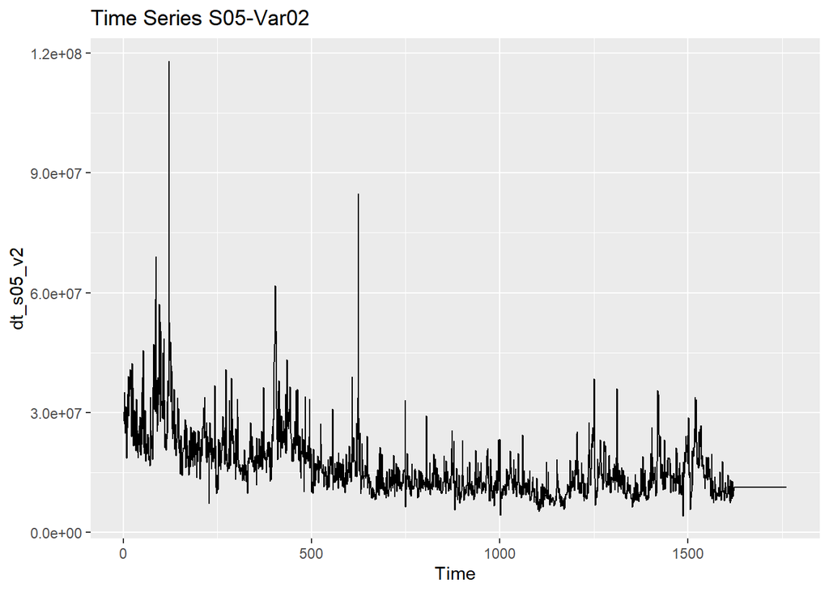

```r
autoplot(dt_s05_v2) + ggtitle("Time Series S05-Var02")
```

Trend non seasonal time series

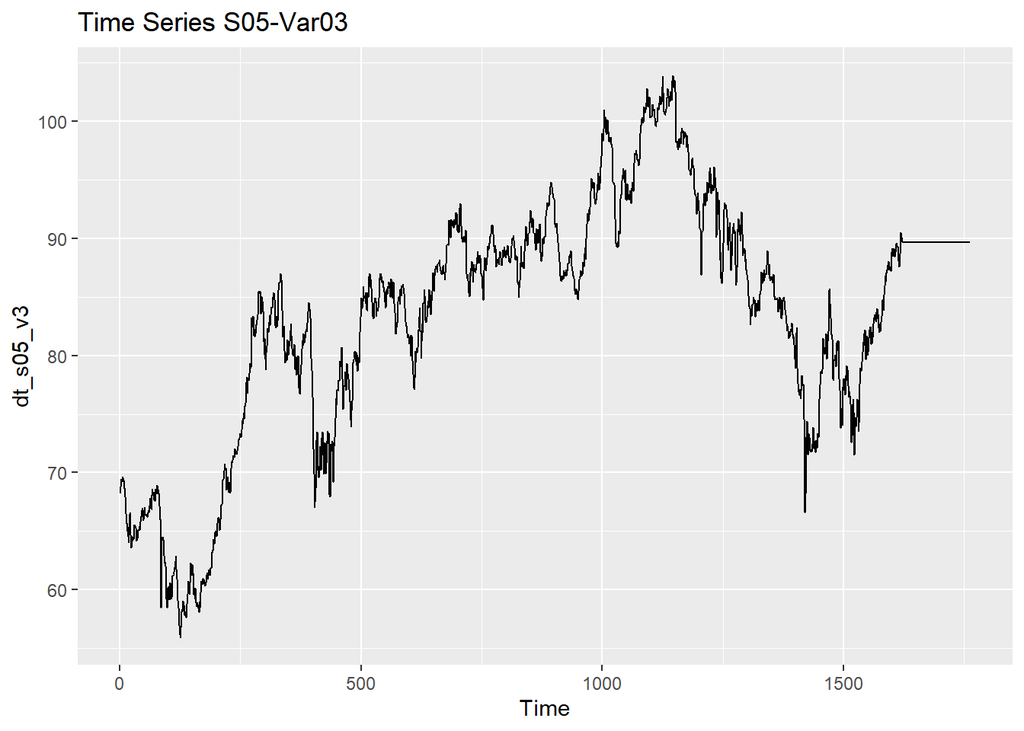

```r
autoplot(dt_s05_v3) + ggtitle("Time Series S05-Var03")
```

Trend non seasonal time serie. It can also be cyclic time series

#### The distribution of data

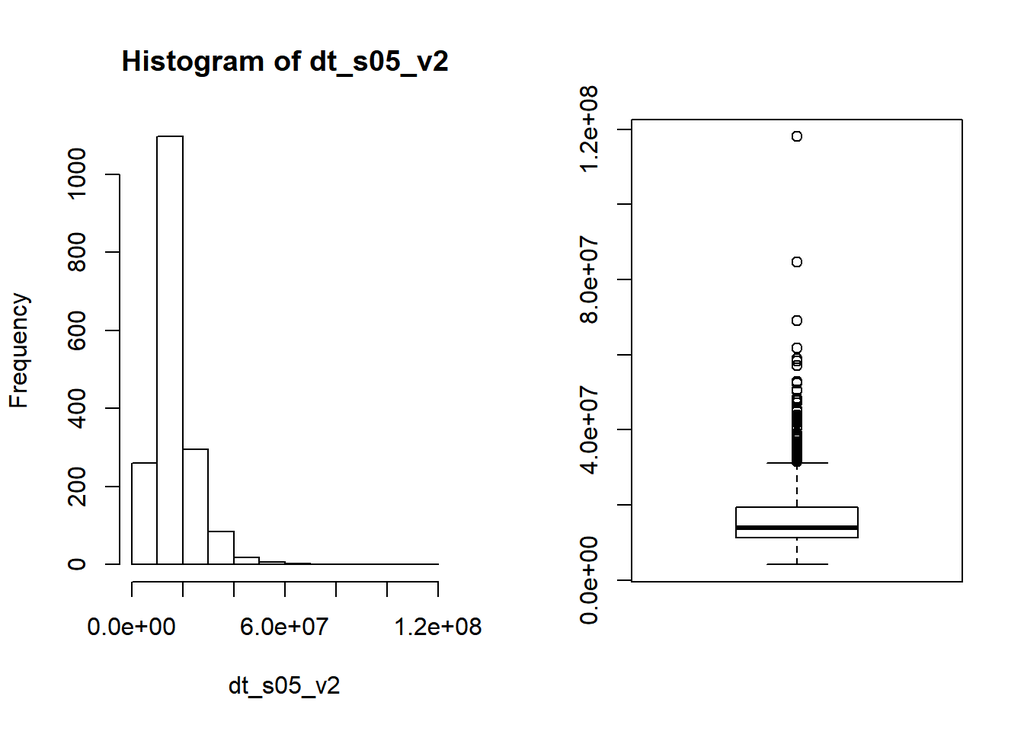

```r
par(mfrow= c(1,2))
hist(dt_s05_v2)
boxplot(dt_s05_v2)
```

Va02 is right skewed. We can supress the ultimate outliers that skew the distribution then transform the data.

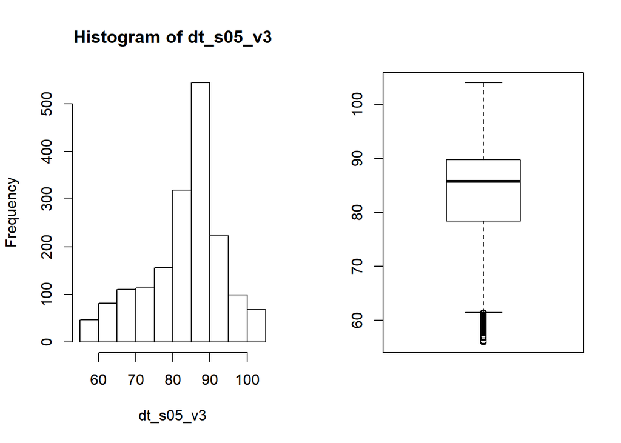

```r
par(mfrow= c(1,2))
hist(dt_s05_v3)
boxplot(dt_s05_v3)
```

Var03 is nearly normal distributed and has outliers at the left.

#### Removing the oulier

```r
# check outlier(s)
dt_s05_v2_out <- tsoutliers(dt_s05_v2)
dt_s05_v3_out <- tsoutliers(dt_s05_v3)
```

```r
dt_s05_v2 <- tsclean(dt_s05_v2)
dt_s05_v3 <- tsclean(dt_s05_v3)
```

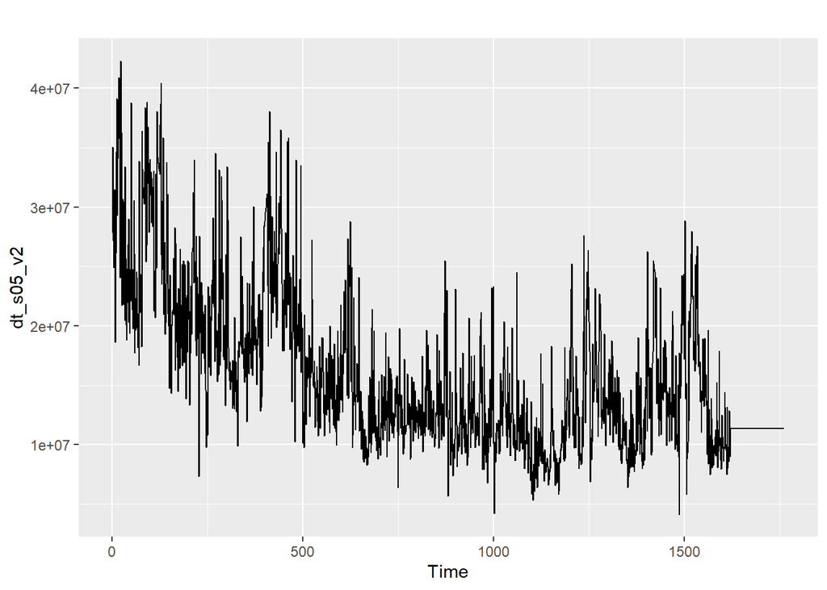

```r
autoplot(dt_s05_v2)
```

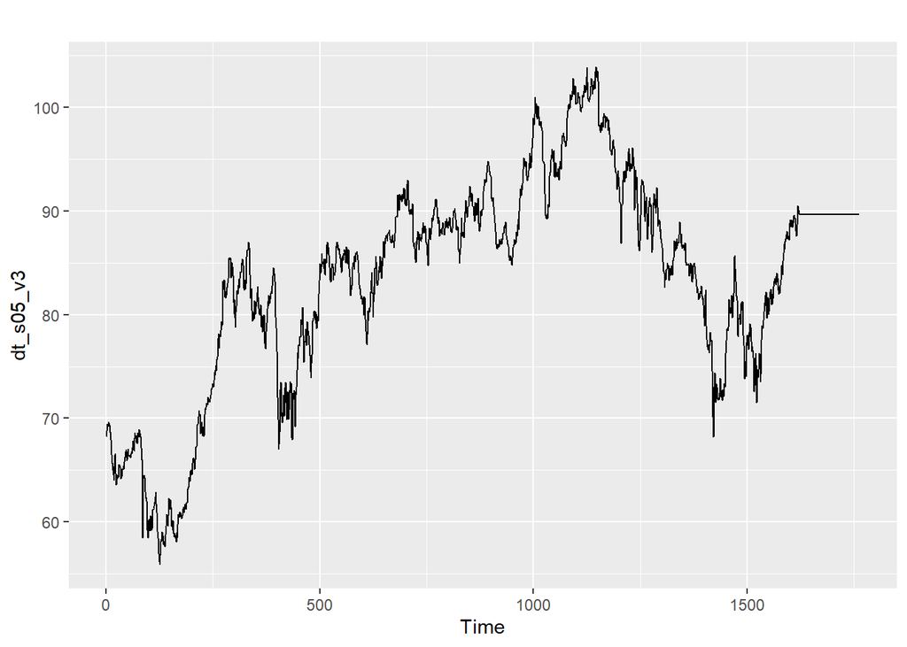

```r
autoplot(dt_s05_v3)
```

#### Correlation between V02 and V03 variables

There exists a linear correlation between V02 and V03 This is prove by the correlation test below

```r
cor.test(dt_s05_v2, dt_s05_v3)
```

```
##
##  Pearson's product-moment correlation
##
## data:  dt_s05_v2 and dt_s05_v3
## t = -44.357, df = 1760, p-value < 2.2e-16
## alternative hypothesis: true correlation is not equal to 0
## 95 percent confidence interval:
##  -0.7478479 -0.7036987
## sample estimates:
##        cor
## -0.7265222
```

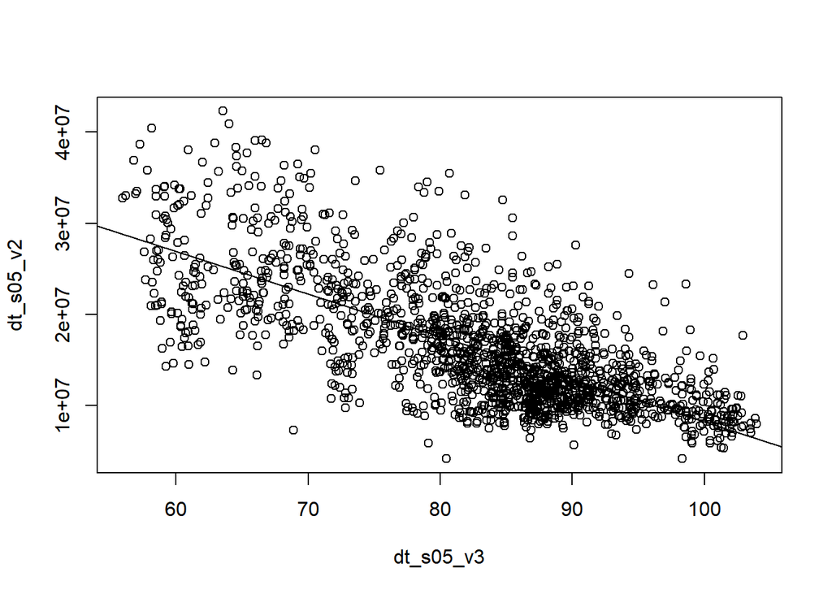

```
## integer(0)
```

```r
lmodel <- lm(dt_s05_v2~dt_s05_v3)
plot(x = dt_s05_v3, y = dt_s05_v2)+abline(lmodel)
```

```r
(cor(dt_s05_v2,dt_s05_v3))^2
```

```
##           Var03
## Var02 0.5278345
```

#### Verify the seasonalities and trends

ACF of Var02 difference

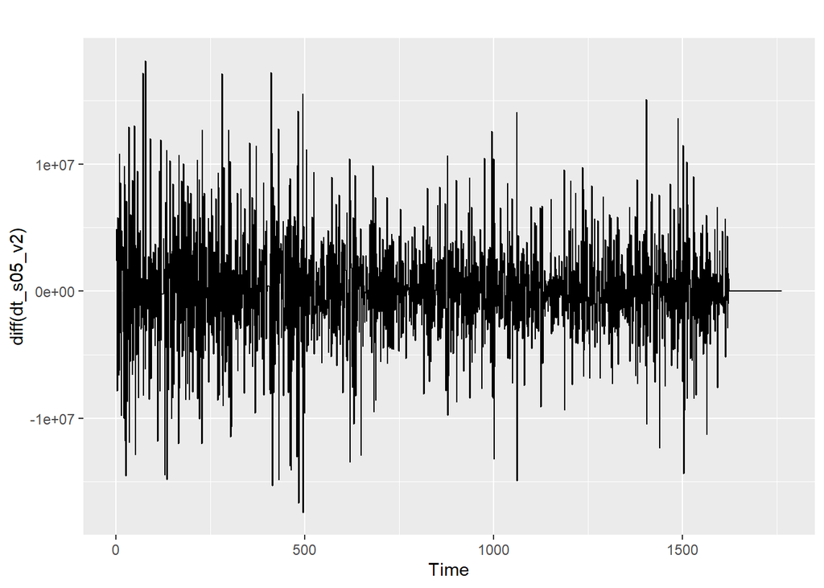

```r
autoplot(diff(dt_s05_v2))
```

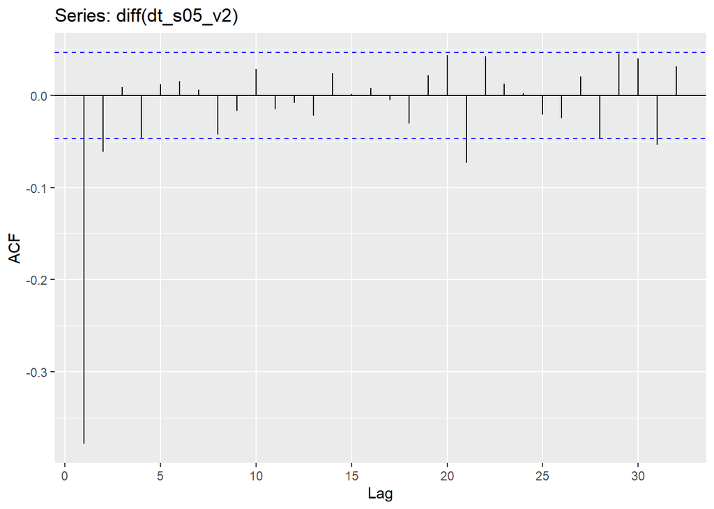

```r
ggAcf(diff(dt_s05_v2))
```

There is one order autocorrelation This data has no seasonality

ACF of Var03 difference

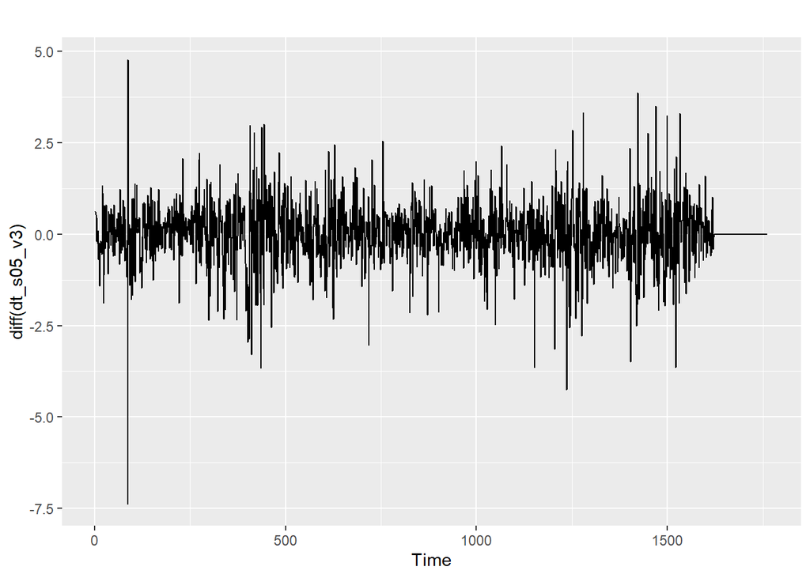

```r
autoplot(diff(dt_s05_v3))
```

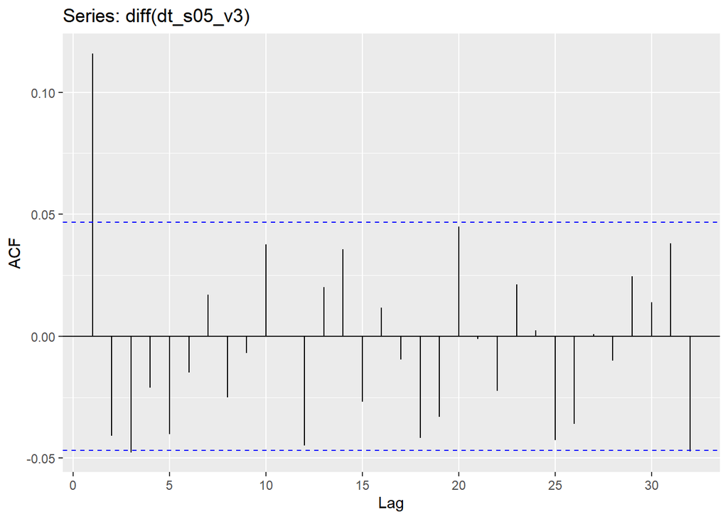

```r
ggAcf(diff(dt_s05_v3))
```

The ACF shows one order correlation seasonality is insignificant.

#### Subset the train set

```r
dt_s05_v2_train <- window(dt_s05_v2, end = as.integer(length(dt_s05_v2)*0.8))
```

```r
dt_s05_v3_train <- window(dt_s05_v3, end = as.integer(length(dt_s05_v3)*0.8))
```

#### Look for lambda transformation

```r
lambda2 <- BoxCox.lambda(dt_s05_v2)
```

```r
lambda3 <- BoxCox.lambda(dt_s05_v3)
```

#### Apply the models to the train sets

The forecast horizon here is the length of test set

```r
h_test <- length(dt_s05_v2)- as.integer(length(dt_s05_v2)*0.8)
h_test
```

```
## [1] 353
```

Get the arima model for Var02

```r
dt_s05_v2_farima_fit <- dt_s05_v2_train %>% auto.arima(lambda = lambda2, stepwise = FALSE) %>% forecast(h = h_test)
```

Get the arima model for Var03

```r
dt_s05_v3_farima_fit <- dt_s05_v3_train %>% auto.arima(lambda = lambda3, stepwise = FALSE) %>% forecast(h = h_test)
```

#### ETS model

Get the ets model for Var02

```r
dt_s05_v2_fets_fit <- dt_s05_v2_train %>% ets(lambda = lambda2) %>% forecast(h = h_test)
```

Get the arima ets for Var03

```r
dt_s05_v3_fets_fit <- dt_s05_v3_train %>% ets(lambda = lambda3) %>% forecast(h = h_test)
```

#### Naive method

Naive method for Var02

```r
dt_s05_v2_naive_fit <- naive(dt_s05_v2_train, h=h_test)
```

Naive method for Var03

```r
dt_s05_v3_naive_fit <- naive(dt_s05_v3_train, h=h_test)
```

### Accuracy compare to the naive model

#### MAPE accuracy of Var02 models

arima model

```r
s05_v2_farima_ac <- accuracy(dt_s05_v2_farima_fit, dt_s05_v2)["Test set", "MAPE"]
```

ets model

```r
s05_v2_ets_ac <- accuracy(dt_s05_v2_fets_fit, dt_s05_v2)["Test set", "MAPE"]
```

naive model

```r
s05_v2_naive_ac <- accuracy(dt_s05_v2_naive_fit, dt_s05_v2)["Test set", "MAPE"]
```

#### MAPE accuracy for Var03 models

arima model

```r
s05_v3_farima_ac <- accuracy(dt_s05_v3_farima_fit, dt_s05_v3)["Test set", "MAPE"]
```

ets model

```r
s05_v3_ets_ac <- accuracy(dt_s05_v3_fets_fit, dt_s05_v3)["Test set", "MAPE"]
```

naive method

```r
s05_v3_naive_ac <- accuracy(dt_s05_v3_naive_fit, dt_s05_v3)["Test set", "MAPE"]
```

Using MAPE for accuracy, the naive method for Var03 is better than the arima of the same data. ETS model is the best. ### MAPE ACCURACY

```r
s05_v2_MAPE <- c(s05_v2_farima_ac, s05_v2_ets_ac, s05_v2_naive_ac)
s05_v3_MAPE <- c(s05_v3_farima_ac, s05_v3_ets_ac, s05_v3_naive_ac)
s05_MAPE <- matrix(rbind(s05_v2_MAPE, s05_v3_MAPE), nrow = 2 )
rownames(s05_MAPE) <- c("S05_V02", "S05_V03")
colnames(s05_MAPE) <- c("Arima", "ETS", "Naive")
data.frame(s05_MAPE)
```

```
##             Arima       ETS     Naive
## S05_V02 21.012551 27.539448 19.190336
## S05_V03  9.539444  9.514966  9.514987
```

### Arima model

```r
dt_s05_v2_farima <- dt_s05_v2 %>% auto.arima(lambda = lambda2, stepwise = FALSE) %>% forecast(h = 140)
```

```r
dt_s05_v3_farima <- dt_s05_v3 %>% auto.arima(lambda = lambda3, stepwise = FALSE) %>% forecast(h = 140)
```

##### Var02 forecast

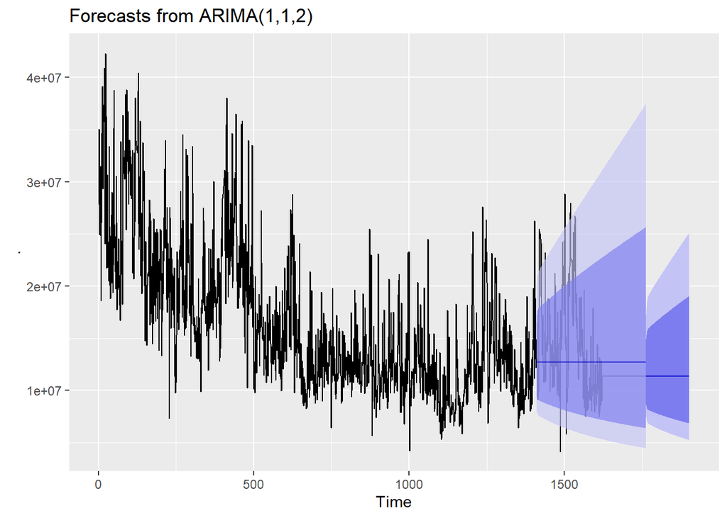

```r
autoplot(dt_s05_v2_farima)+autolayer(dt_s05_v2_farima_fit, alpha = 0.65)
```

##### Var03 forecast

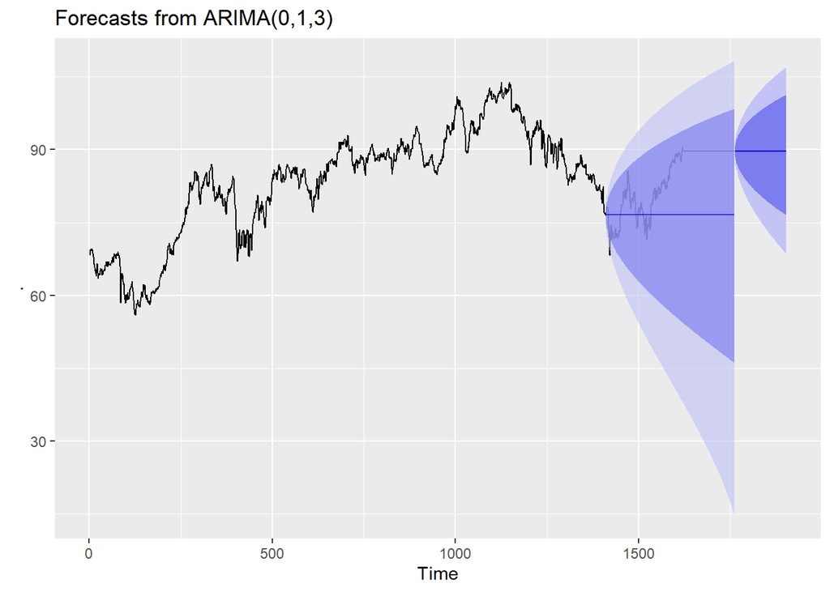

```r
autoplot(dt_s05_v3_farima) + autolayer(dt_s05_v3_farima_fit, alpha = 0.65)
```

#### Check the residuals if the model is valid

##### Var02 residuals

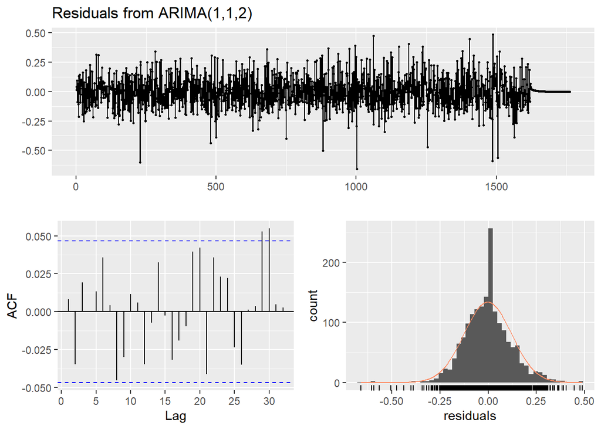

```
##
##  Ljung-Box test
##
## data:  Residuals from ARIMA(1,1,2)
## Q* = 10.935, df = 7, p-value = 0.1415
##
## Model df: 3.   Total lags used: 10
```

```r
checkresiduals(dt_s05_v2_farima)
```

with p-value greater than 0.05, there is convaincing evidence that residuals for Var02 are white noise. On ACF, the residuals are uncorrelated. The histogram shows that the residuals are normal distributed.

##### Var03 residuals

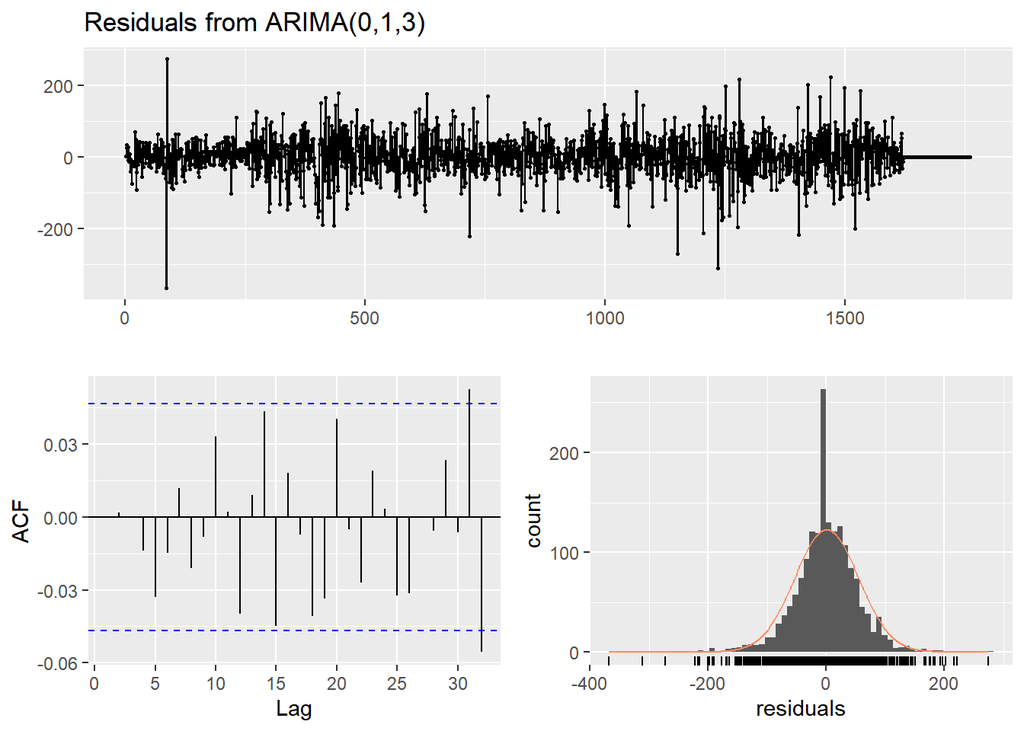

```
##
##  Ljung-Box test
##
## data:  Residuals from ARIMA(0,1,3)
## Q* = 5.7191, df = 7, p-value = 0.5729
##
## Model df: 3.   Total lags used: 10
```

```r
checkresiduals(dt_s05_v3_farima)
```

with p-value greater than 0.05, there is convaincing evidence that residuals for Var03 are white noise. On ACF, the residuals are uncorrelated. The histogram shows that the residuals are normal distributed.

### ETS model

```r
dt_s05_v2_fets <- dt_s05_v2 %>% ets(lambda = lambda2) %>% forecast(h = 140)
```

```r
dt_s05_v3_fets <- dt_s05_v3 %>% ets(lambda = lambda3) %>% forecast(h = 140)
```

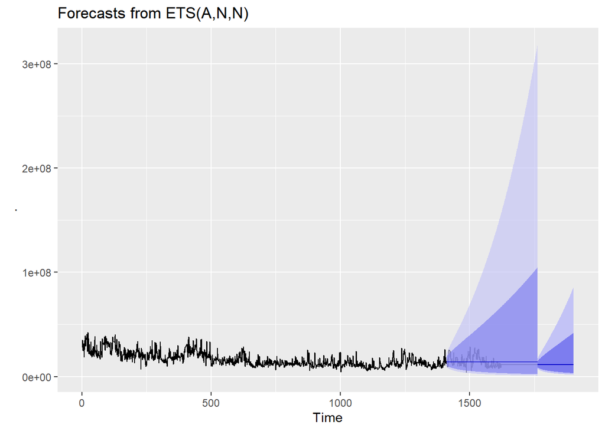

```r
autoplot(dt_s05_v2_fets) + autolayer(dt_s05_v2_fets_fit, alpha = 0.65)
```

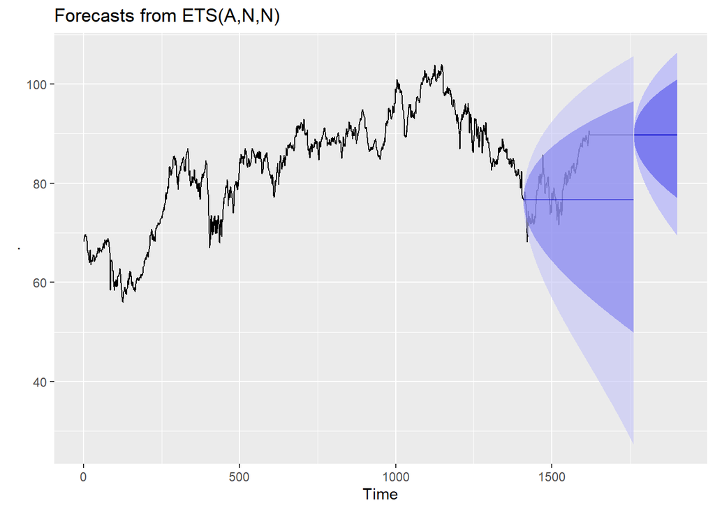

```r
autoplot(dt_s05_v3_fets) + autolayer(dt_s05_v3_fets_fit, alpha = 0.60)
```

#### Check the residuals if the model is valid

##### Var02 residuals

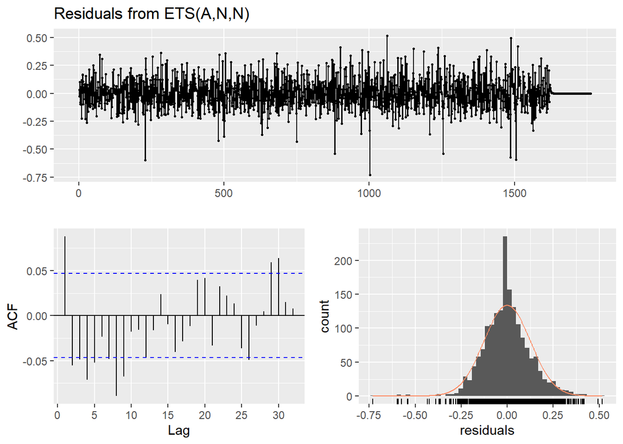

```
##
##  Ljung-Box test
##
## data:  Residuals from ETS(A,N,N)
## Q* = 64.821, df = 8, p-value = 5.236e-11
##
## Model df: 2.   Total lags used: 10
```

```r
checkresiduals(dt_s05_v2_fets)
```

##### Var03 residuals

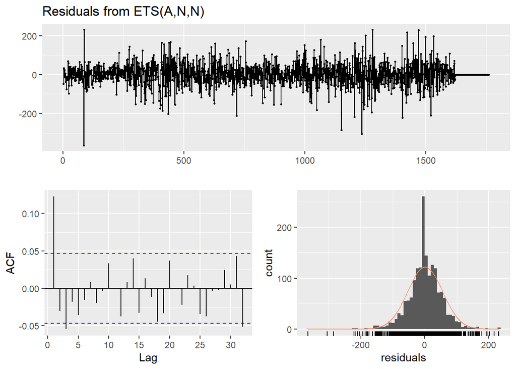

```
##
##  Ljung-Box test
##
## data:  Residuals from ETS(A,N,N)
## Q* = 39.514, df = 8, p-value = 3.945e-06
##
## Model df: 2.   Total lags used: 10
```

```r
checkresiduals(dt_s05_v3_fets)
```

This is the metric MAPE on the entire dataset S05_V02 or S05_V03 using the ETS model

```r
# MAPE
print(paste0("MAPE for S05 Var02 is ", MLmetrics::MAPE(dt_s05_v2_fets_fit$fitted, dt_s05_v2)))
```

```
## [1] "MAPE for S05 Var02 is 0.175540210146137"
```

```r
print(paste0("MAPE for S05 Var03 is ", MLmetrics::MAPE(dt_s05_v3_fets_fit$fitted, dt_s05_v3)))
```

```
## [1] "MAPE for S05 Var03 is 0.00768166112203446"
```

```r
# s05_v2_forecast <- window(dt_s05_v2_fets$fitted, start=1722-139)
# library(xlsx)
# write.xlsx(s05_v2_forecast, "c:\\DATA624\\S05_V02.xlsx")
```

```r
# s05_v3_forecast <- window(dt_s05_v3_fets$fitted, start=1722-139)
# write.xlsx(s05_v3_forecast, "c:\\DATA624\\S05_V03.xlsx")
```